# exame-continua

## Polynomial Linear Regression Fish Wgt Prediction

https://www.kaggle.com/code/satishgunjal/polynomial-linear-regression-fish-wgt-prediction

### 1. INICI DE LA PRÀCTICA

```python
import numpy as np
import pandas as pd
import matplotlib.pyplot as plt
import seaborn as sns
from sklearn import linear_model
from sklearn.model_selection import train_test_split
import sklearn.metrics as metrics
from sklearn.preprocessing import PolynomialFeatures

df = pd.read_csv('https://raw.githubusercontent.com/satishgunjal/datasets/master/Fish.csv')
print('Dimension of dataset= ', df.shape)
df.head(5) # head(n) returns first n records only. Can also use sample(n) for random n records.
```

```
Dimension of dataset=  (159, 7)
```

|  | Species | Weight | Length1 | Length2 | Length3 | Height | Width |
| --- | --- | --- | --- | --- | --- | --- | --- |
| 0 | Bream | 242.0 | 23.2 | 25.4 | 30.0 | 11.5200 | 4.0200 |
| 1 | Bream | 290.0 | 24.0 | 26.3 | 31.2 | 12.4800 | 4.3056 |
| 2 | Bream | 340.0 | 23.9 | 26.5 | 31.1 | 12.3778 | 4.6961 |
| 3 | Bream | 363.0 | 26.3 | 29.0 | 33.5 | 12.7300 | 4.4555 |
| 4 | Bream | 430.0 | 26.5 | 29.0 | 34.0 | 12.4440 | 5.1340 |

```python
df1 = df.rename(columns={'Length1':'VerticalLen','Length2':'DiagonalLen','Length3':'CrossLen'})
df1.sample(5) # Display random 5 records
df1.info()
df1.corr()
```

```
<class 'pandas.core.frame.DataFrame'>
RangeIndex: 159 entries, 0 to 158
Data columns (total 7 columns):
 #   Column       Non-Null Count  Dtype
---  ------       --------------  -----
 0   Species      159 non-null    object
 1   Weight       159 non-null    float64
 2   VerticalLen  159 non-null    float64
 3   DiagonalLen  159 non-null    float64
 4   CrossLen     159 non-null    float64
 5   Height       159 non-null    float64
 6   Width        159 non-null    float64
dtypes: float64(6), object(1)
memory usage: 8.8+ KB
```

|  | Weight | VerticalLen | DiagonalLen | CrossLen | Height | Width |
| --- | --- | --- | --- | --- | --- | --- |
| Weight | 1.000000 | 0.915712 | 0.918618 | 0.923044 | 0.724345 | 0.886507 |
| VerticalLen | 0.915712 | 1.000000 | 0.999517 | 0.992031 | 0.625378 | 0.867050 |
| DiagonalLen | 0.918618 | 0.999517 | 1.000000 | 0.994103 | 0.640441 | 0.873547 |
| CrossLen | 0.923044 | 0.992031 | 0.994103 | 1.000000 | 0.703409 | 0.878520 |
| Height | 0.724345 | 0.625378 | 0.640441 | 0.703409 | 1.000000 | 0.792881 |
| Width | 0.886507 | 0.867050 | 0.873547 | 0.878520 | 0.792881 | 1.000000 |

### 2. NOTES CALCUL DE REGRESIÓ LINEAL I POLINOMIAL (A BANDA) -- (INICI)

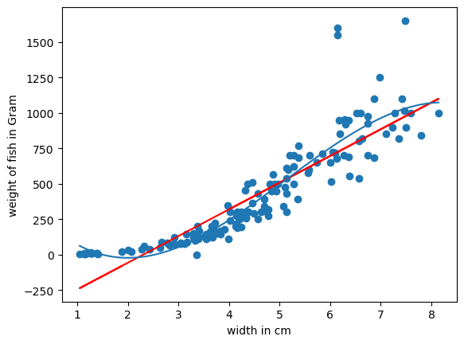

```python
import matplotlib.pyplot as plt
from sklearn.linear_model import LinearRegression
from sklearn.preprocessing import PolynomialFeatures

from sklearn.metrics import r2_score

x = df1.Width.values.reshape(-1,1)
y = df1.Weight.values.reshape(-1,1)

plt.scatter(x,y)
plt.xlabel("width in cm")
plt.ylabel("weight of fish in Gram")


#************** linear regression cizimi *********
fLin_model = LinearRegression()
fLin_model.fit(x,y)

#****** predict *********
y_pred = fLin_model.predict(x)
plt.plot(x, y_pred, color="red", label="linear")

#********* Polynomial Regression *****y = b0 + b1*x1 + b2*x2 + b3*x3 +... ***********
# Subamos al rango 5. si es adecuado

x = df['Width']
y = df['Weight']

fPoly_model = np.poly1d(np.polyfit(x, y, 3))
linea_x = np.linspace(df['Width'].min(), df['Width'].max(), 100)
plt.plot(linea_x, fPoly_model (linea_x))

plt.show()
```

```python
print (fPoly_model.r)
```

```
[11.31408981  2.52627513  1.50437933]
```

```python
print("r2 lineal", r2_score(y, y_pred))
print("r2 Polyn.", r2_score(y, fPoly_model(x)))
```

```
r2 lineal 0.7858939611400793
r2 Polyn. 0.850647313813846
```

```python
print("Lineal Predict weight of fish in 4 cms.", fLin_model.predict([[4]]) , "Grams")
print("Lineal Predict weight of fish in 6 cms.", fLin_model.predict([[6]]), "Grams")
```

```
Lineal Predict weight of fish in 4 cms. [[319.73536657]] Grams
Lineal Predict weight of fish in 6 cms. [[696.23247611]] Grams
```

```python
print("Polinomial Predict weight of fish in 4 cms.", fPoly_model (4) , "Grams")
print("Polinomial Predict weight of fish in 6 cms.", fPoly_model (6), "Grams")
```

```
Polinomial Predict weight of fish in 4 cms. 244.185412330847 Grams
Polinomial Predict weight of fish in 6 cms. 753.3181090412488 Grams
```

### FI DE LES NOTES CALCUL DE REGRESI LINEAL I POLINOMIAL (A BANDA)

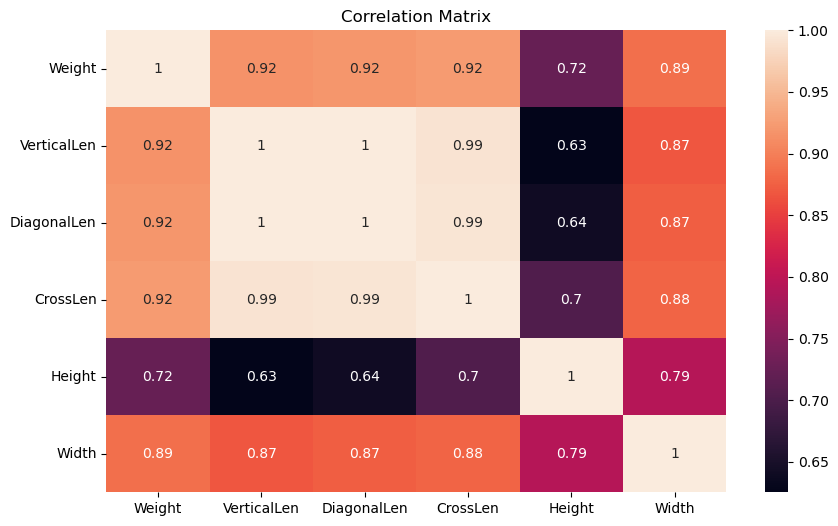

```python
plt.rcParams["figure.figsize"] = (10,6) # Custom figure size in inches
sns.heatmap(df1.corr(), annot =True)
plt.title('Correlation Matrix')
```

```python
df2 = df1.drop(['VerticalLen', 'DiagonalLen', 'CrossLen'], axis =1) # Can also use axis = 'columns'
print('New dimension of dataset is= ', df2.shape)
df2.head(3)
```

```
New dimension of dataset is=  (159, 4)
```

|  | Species | Weight | Height | Width |
| --- | --- | --- | --- | --- |
| 0 | Bream | 242.0 | 11.5200 | 4.0200 |
| 1 | Bream | 290.0 | 12.4800 | 4.3056 |
| 2 | Bream | 340.0 | 12.3778 | 4.6961 |

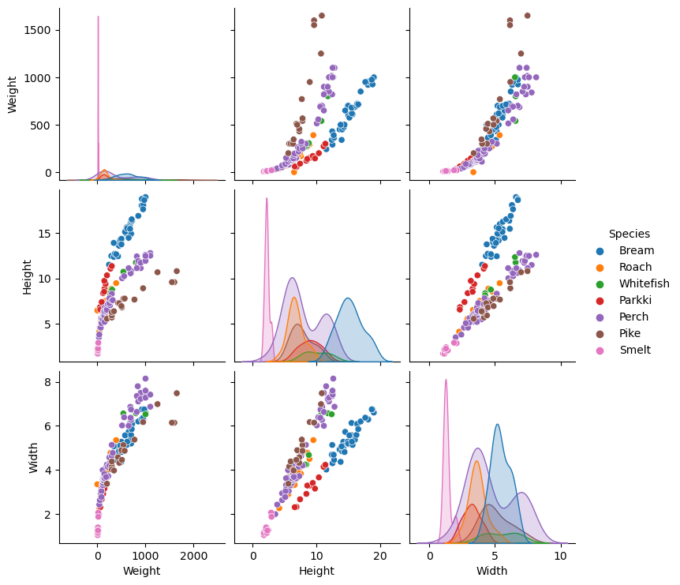

```python
sns.pairplot(df2, kind = 'scatter', hue = 'Species')
```

#### Outlier Detection and Removal

```python
def outlier_detection(dataframe):
    Q1 = dataframe.quantile(0.25)
    Q3 = dataframe.quantile(0.75)
    IQR = Q3 - Q1
    upper_end = Q3 + 1.5 * IQR
    lower_end = Q1 - 1.5 * IQR
    outlier = dataframe[(dataframe > upper_end) | (dataframe < lower_end)]
    return outlier
```

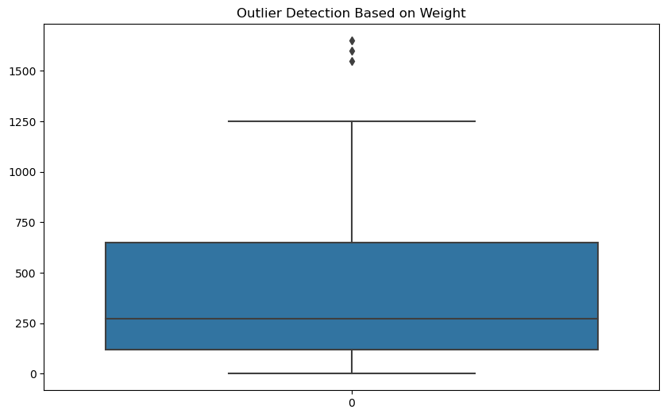

```python
# Outlier detection based on Weight

sns.boxplot(data= df2['Weight'] )
plt.title('Outlier Detection Based on Weight')
```

```python
# 'Species' column contains categorical values, so using list slicing to iterate over all the columns except first one
for column in df2.columns[1:]:
    print('\nOutliers in column "%s" ' % column)
    outlier = outlier_detection(df2[column])
    print(outlier)
```

```
Outliers in column "Weight"
142    1600.0
143    1550.0
144    1650.0
Name: Weight, dtype: float64

Outliers in column "Height"
Series([], Name: Height, dtype: float64)

Outliers in column "Width"
Series([], Name: Width, dtype: float64)
```

```python
#Lets create temp dataframe without 'Weight' feature for plotting the boxplot
df_temp = df2.drop(['Weight'], axis = 'columns')
```

#### Outlier detection for Perch species

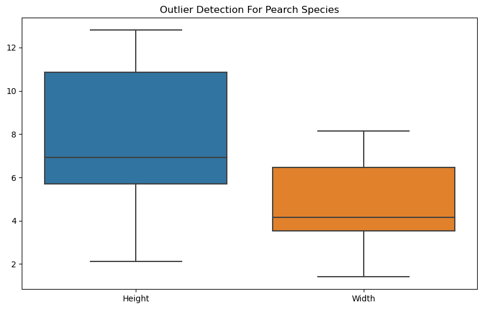

```python
sns.boxplot(data= df_temp[df_temp.Species == 'Perch'] )
plt.title('Outlier Detection For Pearch Species')
```

```python
df_Perch = df2[df2.Species == 'Perch']
for column in df_Perch.columns[1:]:
    print('\nOutliers in column "%s" ' % column)
    outlier = outlier_detection(df_Perch[column])
    print(outlier)

# There are no outliers for 'Perch' fish species
```

```
Outliers in column "Weight"
Series([], Name: Weight, dtype: float64)

Outliers in column "Height"
Series([], Name: Height, dtype: float64)

Outliers in column "Width"
Series([], Name: Width, dtype: float64)
```

#### Outlier detection for Bream species

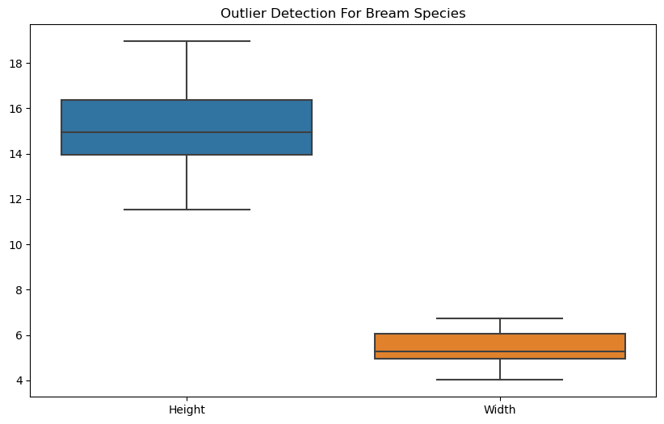

```python
sns.boxplot(data= df_temp[df_temp.Species == 'Bream'] )
plt.title('Outlier Detection For Bream Species')
```

```python
df_Bream = df2[df2.Species == 'Bream']
for column in df_Bream.columns[1:]:
    print('\nOutliers in column "%s" ' % column)
    outlier = outlier_detection(df_Bream[column])
    print(outlier)


# There are no outliers for 'Bream' species
```

```
Outliers in column "Weight"
Series([], Name: Weight, dtype: float64)

Outliers in column "Height"
Series([], Name: Height, dtype: float64)

Outliers in column "Width"
Series([], Name: Width, dtype: float64)
```

#### Outlier detection for Roach species

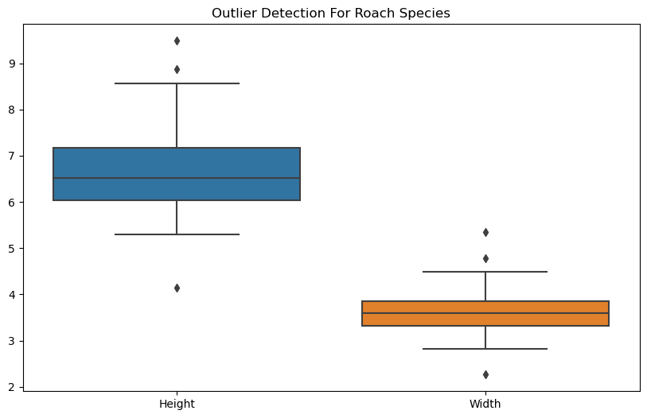

```python
sns.boxplot(data= df_temp[df_temp.Species == 'Roach'] )
plt.title('Outlier Detection For Roach Species')
```

```python
df_Roach = df2[df2.Species == 'Roach']
for column in df_Roach.columns[1:]:
    print('\nOutliers in column "%s" ' % column)
    outlier = outlier_detection(df_Roach[column])
    print(outlier)
# We can see only row 54 and 35 are common across majority features,
# so we can safely remove them
```

```
Outliers in column "Weight"
40      0.0
52    290.0
54    390.0
Name: Weight, dtype: float64

Outliers in column "Height"
35    4.1472
52    8.8768
54    9.4850
Name: Height, dtype: float64

Outliers in column "Width"
35    2.2680
53    4.7736
54    5.3550
Name: Width, dtype: float64
```

#### Outlier detection for Pike species

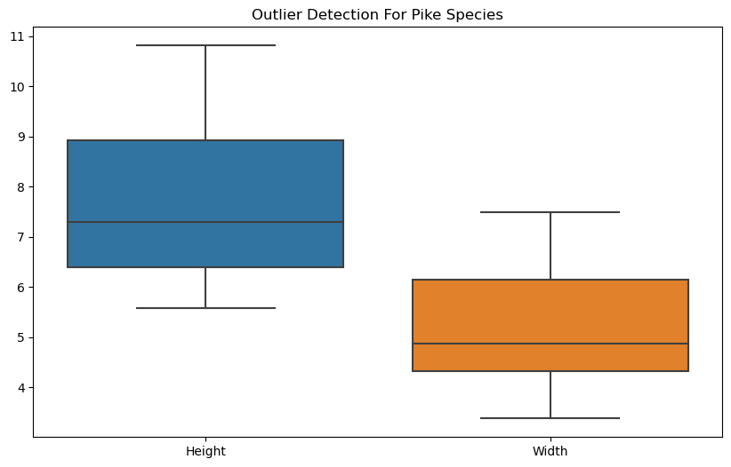

```python
sns.boxplot(data= df_temp[df_temp.Species == 'Pike'] )
plt.title('Outlier Detection For Pike Species')
```

```python
df_Pike = df2[df2.Species == 'Pike']
for column in df_Pike.columns[1:]:
    print('\nOutliers in column "%s" ' % column)
    outlier = outlier_detection(df_Pike[column])
    print(outlier)
# No outlier for Pike species
```

```
Outliers in column "Weight"
Series([], Name: Weight, dtype: float64)

Outliers in column "Height"
Series([], Name: Height, dtype: float64)

Outliers in column "Width"
Series([], Name: Width, dtype: float64)
```

#### Outlier detection for Smelt species

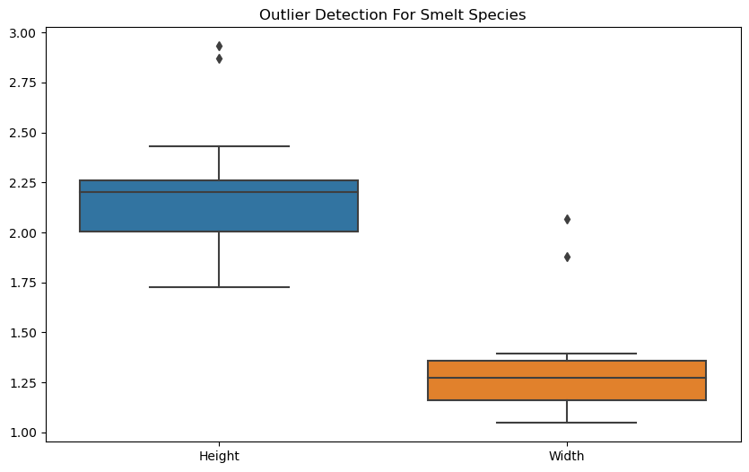

```python
sns.boxplot(data= df_temp[df_temp.Species == 'Smelt'] )
plt.title('Outlier Detection For Smelt Species')
```

```python
df_Smelt = df2[df2.Species == 'Smelt']
for column in df_Smelt.columns[1:]:
    print('\nOutliers in column "%s" ' % column)
    outlier = outlier_detection(df_Smelt[column])
    print(outlier)
# We can see only rows 157 and 158 are common across multiple features,
# so we can safely remove them
```

```
Outliers in column "Weight"
157    19.7
158    19.9
Name: Weight, dtype: float64

Outliers in column "Height"
157    2.8728
158    2.9322
Name: Height, dtype: float64

Outliers in column "Width"
157    2.0672
158    1.8792
Name: Width, dtype: float64
```

#### Outlier detection for Parkki species

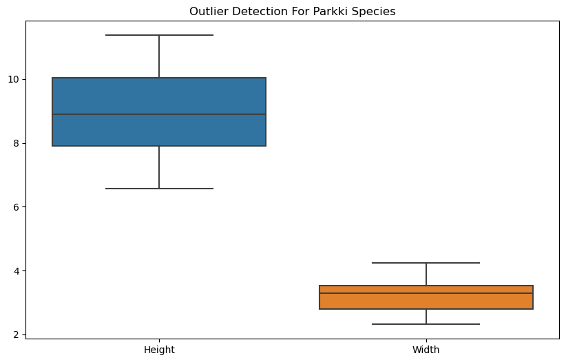

```python
sns.boxplot(data= df_temp[df_temp.Species == 'Parkki'] )
plt.title('Outlier Detection For Parkki Species')
```

```python
df_Parkki = df2[df2.Species == 'Parkki']
for column in df_Parkki.columns[1:]:
    print('\nOutliers in column "%s" ' % column)
    outlier = outlier_detection(df_Parkki[column])
    print(outlier)
# No outliers for Parkki species
```

```
Outliers in column "Weight"
Series([], Name: Weight, dtype: float64)

Outliers in column "Height"
Series([], Name: Height, dtype: float64)

Outliers in column "Width"
Series([], Name: Width, dtype: float64)
```

#### Outlier detection for Whitefish species

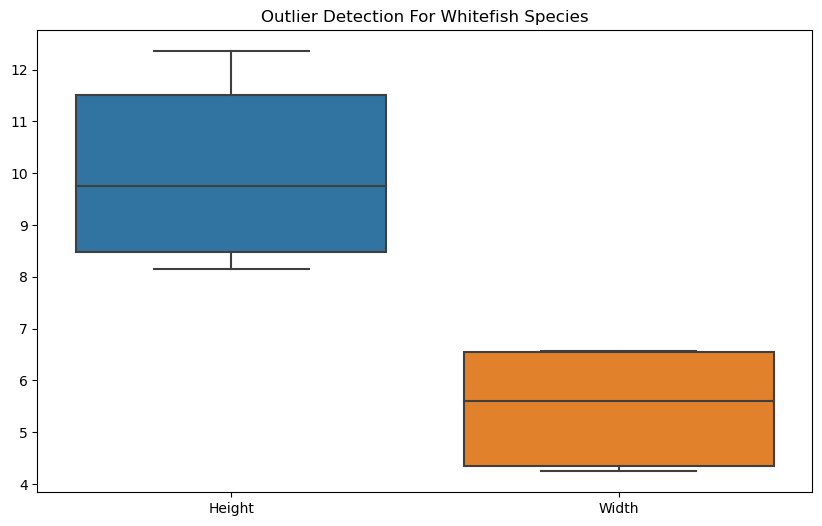

```python
sns.boxplot(data= df_temp[df_temp.Species == 'Whitefish'] )
plt.title('Outlier Detection For Whitefish Species')
```

```python
df_Whitefish = df2[df2.Species == 'Whitefish']
for column in df_Whitefish.columns[1:]:
    print('\nOutliers in column "%s" ' % column)
    outlier = outlier_detection(df_Whitefish[column])
    print(outlier)
# No outlier for Whitefish species
```

```
Outliers in column "Weight"
Series([], Name: Weight, dtype: float64)

Outliers in column "Height"
Series([], Name: Height, dtype: float64)

Outliers in column "Width"
Series([], Name: Width, dtype: float64)
```

#### Dropping the outlier rows

- If we don't consider species specific measurement then outlier are 142, 143 and 144
- And as per species specific measurement outliers are 35, 54, 157 and 158
- Lets drop the species specific outliers only

```python
df3 = df2.drop([35,54,157,158])
df3.shape
```

```
(155, 4)
```

#### Check for null values

```python
df3.isna().sum()
```

```
Species    0
Weight     0
Height     0
Width      0
dtype: int64
```

#### Using Domain Knowledge For Data Cleaning

Now lets use some common sense and find and remove the training data where weight of fish is 0 or negative

```python
df3[df3.Weight <= 0]
```

|  | Species | Weight | Height | Width |
| --- | --- | --- | --- | --- |
| 40 | Roach | 0.0 | 6.4752 | 3.3516 |

```python
df4 = df3.drop([40])
df4.shape
```

```
(154, 4)
```

#### One Hot Encoding

Since Species is categorical value, we are going to use One Hot Encoding to convert it into numerical format.

```python
dummies_species = pd.get_dummies(df4.Species) # store the dummy variables in 'dummies_species' dataframe
dummies_species.head(3) # To do get individual dummy value
```

|  | Bream | Parkki | Perch | Pike | Roach | Smelt | Whitefish |
| --- | --- | --- | --- | --- | --- | --- | --- |
| 0 | 1 | 0 | 0 | 0 | 0 | 0 | 0 |
| 1 | 1 | 0 | 0 | 0 | 0 | 0 | 0 |
| 2 | 1 | 0 | 0 | 0 | 0 | 0 | 0 |

```python
# Now lets create new dataframe using dummies_species dataframe
df5 = pd.concat([df4, dummies_species],axis = 'columns')
df5.head(3)
```

|  | Species | Weight | Height | Width | Bream | Parkki | Perch | Pike | Roach | Smelt | Whitefish |
| --- | --- | --- | --- | --- | --- | --- | --- | --- | --- | --- | --- |
| 0 | Bream | 242.0 | 11.5200 | 4.0200 | 1 | 0 | 0 | 0 | 0 | 0 | 0 |
| 1 | Bream | 290.0 | 12.4800 | 4.3056 | 1 | 0 | 0 | 0 | 0 | 0 | 0 |
| 2 | Bream | 340.0 | 12.3778 | 4.6961 | 1 | 0 | 0 | 0 | 0 | 0 | 0 |

```python
# Since we have dummy variables we can drop the 'Species' column
# and to avoide the 'Dummy Variable Trap' problem we will also
# drop 'Whitefish' column
df6 = df5.drop(['Species','Whitefish'], axis = 'columns')
df6.head(3)
```

|  | Weight | Height | Width | Bream | Parkki | Perch | Pike | Roach | Smelt |
| --- | --- | --- | --- | --- | --- | --- | --- | --- | --- |
| 0 | 242.0 | 11.5200 | 4.0200 | 1 | 0 | 0 | 0 | 0 | 0 |
| 1 | 290.0 | 12.4800 | 4.3056 | 1 | 0 | 0 | 0 | 0 | 0 |
| 2 | 340.0 | 12.3778 | 4.6961 | 1 | 0 | 0 | 0 | 0 | 0 |

### Build Machine Learning Model

#### Create Feature Matrix X and Label Vector y

```python
X = df6[['Height', 'Width', 'Bream', 'Parkki' ,'Perch', 'Pike', 'Roach', 'Smelt']]
# Or can use df6.iloc[:,[1,2,3,4,5,6,7,8]]
y = df6[['Weight']]

X_train, X_test, y_train, y_test = train_test_split(X,y, test_size = 0.2)
print('X_train dimension= ', X_train.shape)
print('X_test dimension= ', X_test.shape)
print('y_train dimension= ', y_train.shape)
print('y_train dimension= ', y_test.shape)
```

```
X_train dimension=  (123, 8)
X_test dimension=  (31, 8)
y_train dimension=  (123, 1)
y_train dimension=  (31, 1)
```

#### Visualization Using Polynomial Function

- Since we have multiple species, the relation between features(Height, Width) and Weight is not linear
- Line won't be good fit to the given data and may result in under fitting.
- Lets visualize the data using multiple degrees of polynomial
- We are going to use below numpy functions to plot different degrees of polynomial functions
- numpy.polyfit: Used to fit a polynomial function of given degrees. It returns the coefficients (which minimizes the squared error) of the polynomial equation
  - This function takes three arguments to fit a polynomial function to given data. X values, Y values and degrees (1,2,3...n)
    - Polynomial equation of degree 1 is linear equation: y = mx + b
    - Polynomial equation of degree 2 is quadratic equation: y = ax^2 + bx + c
    - So polyfit function will return the coefficients of the polynomial equation. For linear equation coeff will be [m,b] and for quadratic equation coeff will be [a,b,c]
- numpy.poly1d: Is used to define the polynomial function using the coefficients returned by 'numpy.polyfit'
  - It takes polynomial coefficients as argument and construct a polynomial.
  - For e.g. if there are three coeff then it will construct quadratic equation
- numpy.linspace: Takes three arguments (start, stop and num) and generates evenly spaced values(same as 'num') within 'start' and 'stop' range
  - Finaly to draw a polynomial function we will plot 'values' generated 'linspace' function on X axis and on Y axis 'poly_func' output for every 'values'

```python
def polynomial_plot(feature, label):
  # Create 1D array. We can use 'squeeze' function to reduce the 2D array to 1D array
  x_coordinates = feature
  y_coordinates = np.squeeze(label)

 # Contruct first degree polynomial function
  linear_func = np.poly1d(np.polyfit(x_coordinates, y_coordinates, 1))
  # Contruct second degree polynomial function
  quadratic_func = np.poly1d(np.polyfit(x_coordinates, y_coordinates, 2))

  # Generate evenly spaced values
  values = np.linspace(x_coordinates.min(), x_coordinates.max(), len(x_coordinates))

  plt.scatter(x_coordinates,y_coordinates, color='blue')
  plt.plot(values, linear_func(values), color='cyan', linestyle='dashed', label='Linear Function')
  plt.plot(values, quadratic_func(values), color='red', label='Quadratic Function')
  plt.xlabel('%s From Test Data'%(feature.name))
  plt.ylabel('Weight')
  plt.rcParams["figure.figsize"] = (10,6) # Custom figure size in inches
  plt.legend()
  plt.title("Linear Vs Quadratic Function For Feature %s" % (feature.name))
  plt.show()
```

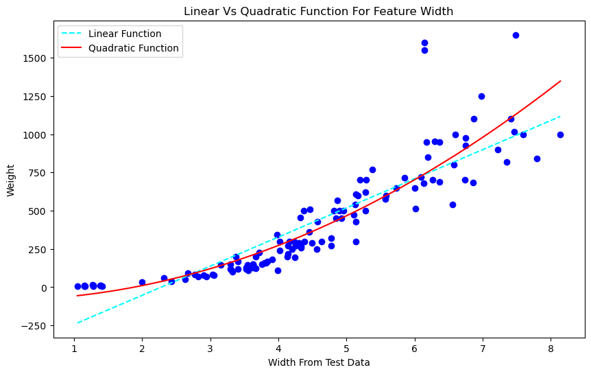

```python
# Lets plot first and second degree polynomical for feature 'Width'.
polynomial_plot(X_train.Width, y_train)
```

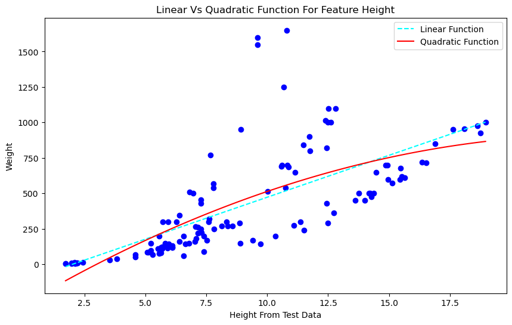

```python
# Lets plot first and second degree polynomical for feature 'Height
polynomial_plot(X_train.Height, y_train)

#From above first and second degree polynomial plots, it's clear that second degree polynomial feature will provide better fit.
```

#### Polynomial Regression Using Sklearn Library

We are going to use second degree polynomial feature, which will give us quadratic equation to fit the data.

```python
poly = PolynomialFeatures(degree = 2)
X_poly = poly.fit_transform(X_train)
poly.fit(X_poly, y_train)
```

```
PolynomialFeatures()
```

#### Ordinary Least Squares Algorithm

Lets the train the model using Ordinary Least Squares Algorithm

This is one of the most basic linear regression algorithm.

The objective of Ordinary Least Square Algorithm is to minimize the residual sum of squares. Here the term residual means 'deviation of predicted value(Xw) from actual value(y)'

Note that, problem with ordinary least square model is size of coefficients increase exponentially with increase in model complexity

```python
lm = linear_model.LinearRegression()
lm.fit(X_poly, y_train)
```

```
LinearRegression()
```

#### Understanding Training Results

```python
predictions = lm.predict(poly.fit_transform(X_test))
print('r2_score= ', metrics.r2_score(y_test, predictions))
```

```
r2_score=  0.9760993625082948
```

#### Model Score

R-squared is statistical measure of how close the data to the fitted regression line. It is also known as coefficient of determination but since we have multiple features here we can also call it 'coefficient of multiple determination'

#### Predicting The Test Data

```python
predictedWeight = pd.DataFrame(predictions, columns=['Predicted Weight']) # Create new dataframe of column'Predicted Weight'
actualWeight = pd.DataFrame(y_test)
actualWeight = actualWeight.reset_index(drop=True) # Drop the index so that we can concat it, to create new dataframe
df_actual_vs_predicted = pd.concat([actualWeight,predictedWeight],axis =1)
df_actual_vs_predicted.T
```

|  | 0 | 1 | 2 | 3 | 4 | 5 | 6 | 7 | 8 | 9 | ... | 21 | 22 | 23 | 24 | 25 | 26 | 27 | 28 | 29 | 30 |
| --- | --- | --- | --- | --- | --- | --- | --- | --- | --- | --- | --- | --- | --- | --- | --- | --- | --- | --- | --- | --- | --- |
| Weight | 850.000000 | 556.000000 | 9.900000 | 78.000000 | 161.000000 | 700.000000 | 140.000000 | 110.000000 | 725.000000 | 685.00000 | ... | 340.000000 | 130.000000 | 170.000000 | 120.000000 | 1000.000000 | 900.000000 | 390.000000 | 920.00000 | 306.00000 | 180.000000 |
| Predicted Weight | 890.096972 | 626.162324 | 9.435804 | 90.103399 | 146.993885 | 686.209191 | 114.344793 | 123.571682 | 752.795883 | 641.56431 | ... | 383.682829 | 156.185305 | 162.839605 | 111.031838 | 936.897362 | 760.289788 | 402.712418 | 908.17396 | 327.40579 | 168.451269 |

2 rows × 31 columns

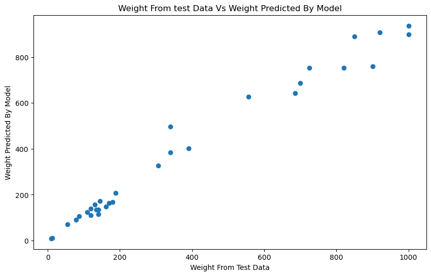

```python
plt.scatter(y_test, predictions)
plt.xlabel('Weight From Test Data')
plt.ylabel('Weight Predicted By Model')
plt.rcParams["figure.figsize"] = (10,6) # Custom figure size in inches
plt.title("Weight From test Data Vs Weight Predicted By Model")
```

### Evaluating the Model

Plot a histogram of the residuals.

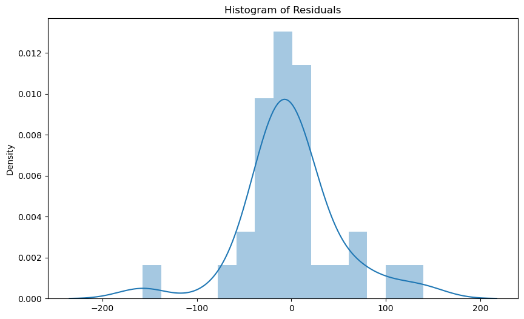

```python
sns.distplot((y_test-predictions))
plt.rcParams["figure.figsize"] = (10,6) # Custom figure size in inches
plt.title("Histogram of Residuals")
```

### Conclusion

- We can see from above results our model score is over 90%, which is very good.
- And there are no negative weight values
- So our approach of finding the outlier based on species and using second degree polynomial features worked!